# The Beginner’s Guide to Grout-fitti

Author

Mia Walker-Saunders

# ✍️ **Grout-fitti**

Imagine this: you’re in the bathroom of your local pub when your eyes drift across the wall and land on a phrase scraped into the grout between tiles:

> “Grout Expectations”

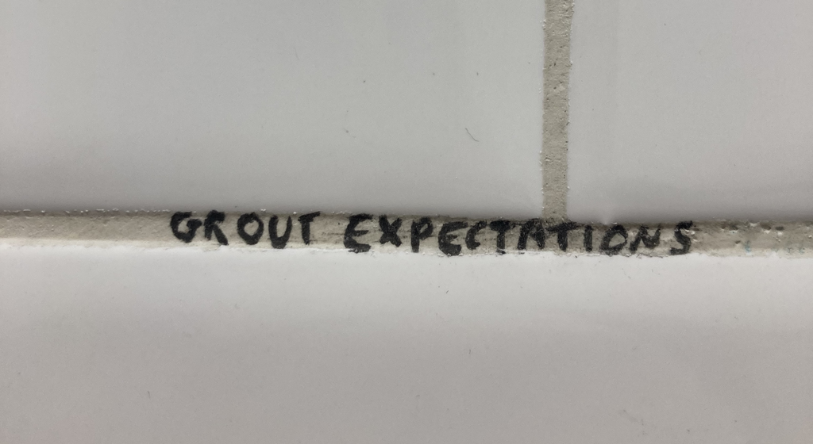

Welcome to the weird world of grout-fitti - where community builds from the phrases inscribed in the gaps between ceramic tiling.

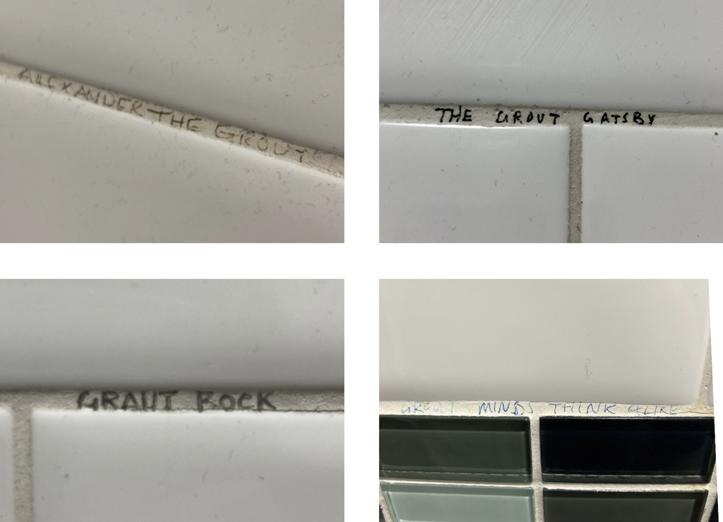

## **🧽 What *Is* Grout Graffiti?**

A unique category of [graffitti](https://en.wikipedia.org/wiki/Graffiti), grout-ffiti is exactly what it sounds like. It’s graffiti, but rather than being spray painted on trains it’s written *between tiles*.

Several examples of grout-fitti were observed in the bathrooms of 📍 [The Basketmakers](https://www.thebasketmakers.pub/) (a pub in Brighton):

| Grout-fitti Observations |
| --- |
| The Groutfather |
| The Grout, The Bad and the Ugly |
| The Grout Escape |
| Grout Expectations |
| Grout Gatbsy |
| Who Let the Dogs Grout |
| Grout, Grout, Let it All Out |
| Twist & Grout |
| Graut Rock |
| You are Groutstanding |
| Grout & Proud |
| Grout Minds Think Alike |
| With Grout Power Comes Grout Responsibility |

## 📖 Reading Between the *(Tile)* Lines

**TipThe theories referenced **are not** empirically linked to the data presented; they are included just for fun!**

There’s something delightfully simple about these Sharpie puns and more to them than meets the eye.

[video not shown]

#### **🧠 Graffiti, Rebellion, and the Human Need to Matter**

Grout-fitti can be interpreted as a form of **territorial marking** and **identity expression**. Textual or visual **latrinalia** (the fancy term for toilet graffitti coined by Alan Dundes in 1966), functions as an informal mode of communication between strangers. Although typically created in a private setting, these messages are intrinsically public in intent. Bathroom graffitti can therefore be interpreted to serve to convey ideas and sometimes even initiate dialogue, transforming a personal moment into an act of social expression (Leong 2015).

This communal act of inscription can be interpreted through the wider lens of Maslow (1943)’s hierarchy of needs. Maslow argues once basic physiological and safety requirements are met, individuals seek belonging, esteem, and self-actualization. In this context, grout-fitti becomes more than just vandalism or humour, and perhaps a method to fulfill our need for belongingness and creativity. It becomes a means of demonstrating that:

> *“I exist. I was here. I have puns to share about grout.”*

#### **😂 What’s with the Puns?**

According to **Incongruity Theory,** an essential component of humour is the element of surprise. Philosophers such as Schopenhauer and Kant have argued that humour stems from cognitive dissonance, and that when expectations are subverted in an unexpected manner, it results in a pleasurable release of this tension through laughter. In line with this interpretation, reading **“Grout Expectations”** in a pub bathroom makes your brain go:

> “Woah! Didn’t expect Dickensian wordplay while drying my hands.”

Conversely, through interpreting grout-fitti through the lense of **Benign Violation Theory** (McGraw and Warren 2010), violation of social norms through the act of vandalism serve as a vital component of grout-fitti’s comedic appeal. The Benign Violation Theory proposes that humour arises when a situation simultaneously represents a violation of social, cultural, or linguistic norms yet is simultaneously perceived as non-threatening or acceptable.

Grafitti is frequently categorised as a sign of juvenile delinquency, anti-social behaviour and criminal activity (Halsey and Young 2006). A pun written in grout in a public toilet constitutes a violation of social norms through the defacement of public property that is rendered benign by the inoffensive nature of the wordplay. The humour therefore emerges from the grout-fitti observer’s ability to recognise both the norm violation and its benign nature simultaneously.

### 📊 **Grout-fitti Themes**

There were a number of key themes observed from the puns scrawled on the grout:

Table 1: Bar Chart of Groutfitti Themes

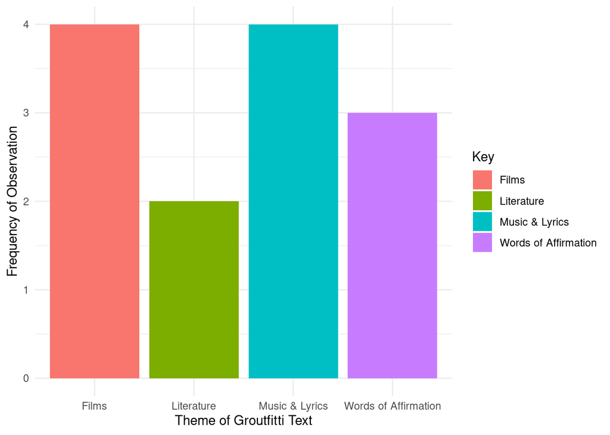

Considering that latrinalia largely occurs in gender-segregated bathrooms, much of the research into the phenomenon has contrasted the ways in which each gendered space is constructed (Amevuvor and Hafer 2018). In contradiction of findings that men’s larinalia tended to contain more vulgarities and insults, whilst women’s latrinalia tended to be more supportive and relationship-centred in tone (Arluke, Kutakoff, and Levin 1987), (Leong 2015), (Amevuvor and Hafer 2018), there were no observed differences in the frequency and tone of textual graffitti between the women’s and men’s bathrooms.

## 💬 **A Message Between the Lines**

Grout-ffiti is oddly uplifting and an optimistic reminder that even in the least poetic places, people still reach for enterprising means of creative catharsis and connection.

Technically, yes, it is vandalism. But it’s also proof that someone was here, had something to say, and chose a *grout* pun to express it.

[figure not shown]

**WarningEngage in grout-fitti at your own risk… or at least out of view of CCTV**

## References

Amevuvor, Jocelyn, and Greg Hafer. 2018. “Communities in the Stalls: A Study of Latrinalia Linguistic Landscapes.” *Critical Inquiry in Language Studies* 16 (2): 90–106. https://doi.org/10.1080/15427587.2018.1446141.

Arluke, Arnold, Lanny Kutakoff, and Jack Levin. 1987. “Are the Times Changing? An Analysis of Gender Differences in Sexual Graffiti.” *Sex Roles* 16 (1-2): 1–7. https://doi.org/10.1007/bf00302846.

Halsey, Mark, and Alison Young. 2006. “‘Our Desires Are Ungovernable’.” *Theoretical Criminology* 10 (3): 275–306. https://doi.org/10.1177/1362480606065908.

Leong, Pamela. 2015. “American Graffiti: Deconstructing Gendered Communication Patterns in Bathroom Stalls.” *Gender, Place & Culture* 23 (3): 306–27. https://doi.org/10.1080/0966369x.2014.991705.

Maslow, A. H. 1943. “A Theory of Human Motivation.” *Psychological Review* 50 (4): 370–96. https://doi.org/10.1037/h0054346.

McGraw, A. Peter, and Caleb Warren. 2010. “Benign Violations.” *Psychological Science* 21 (8): 1141–49. https://doi.org/10.1177/0956797610376073.